# ABT Dataset - Tuned Parameters with PCA optimization

## Clustering

```r
set.seed(123)
sce_cluster<-Cluster(sce_PCA, use.subsamples = TRUE, method = "louvian", k_nn = 10, conf = 0.75)
```

```
1320 samples and 950 genes used for clustering.
Build Graph with 1320 samples...Done.
Louvain Partitioning...Done.
Find nearest neighbours among sub-samples...Done.
Post-hoc Cluster Assignment...Done.
Unassigned Cells 520
Number of Predicted Clusters: 6
```

Clustering is carried out in two alternate approaches on the sampled cells. For the default setting or quick identification of the existing broad clusters, a Louvain based partition is employed. Otherwise for fine-tuned clustering with outliers, hierarchical clustering is used with cutreeDynamic for dendrogram cut. Also, Assigns cluster membership to unsampled cells by using cluster membership information of the nearest neighbours. An approximate nearest neighbour graph is constructed out of the samples population using the find_ann() module. Some cells are left un-assigned when its neighbour’s cluster membership doesn’t form a majority as specified by the conf parameter. Unassigned cells (NA) are excluded in the plot or further downstream analysis.

## Visualizing clusters

```r
set.seed(123)
sce_plot<-PlotEmbedding(sce_cluster, embedding = "umap", spread = 10, min_dist = 0.1)
```

```
UMAP Embedding...Done.
Post-hoc co-ordinate assignment...Done.
```

```r
plot_data = data.frame("Y1" = reducedDim(sce_plot,"umap")[,1], Y2 = reducedDim(sce_plot, "umap")[,2], color = sce_plot$ClusterIDs)
```

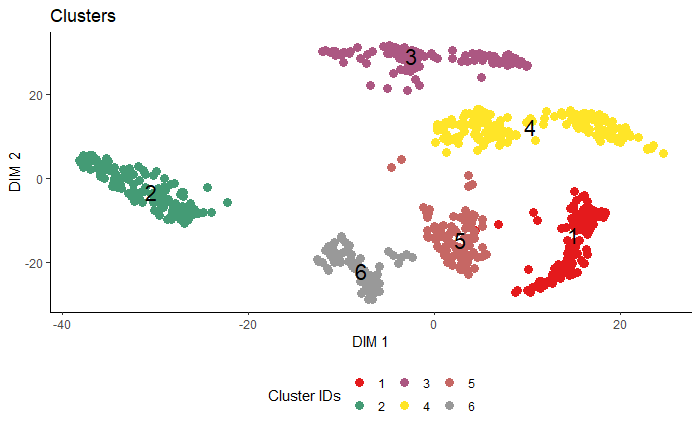

```r
ScatterPlot(sce_plot,title = "Clusters")
```

## Metric

```r
clusterIDs <- colData(sce_cluster)[,"Sample_ClusterIDs"]
data <- matrix(counts(sce_cluster),nrow = length(clusterIDs))
Dist <- dist(data,method="euclidean")
x <- dunn(clusters=as.vector(clusterIDs),distance = Dist)
print(x)
```

```
[1] 0.09200839
```

Description -> Calculates the Dunn Index for a given clustering partition.

*dunn(distance = NULL, clusters, Data = NULL, method = “euclidean”)*

distance -> The distance matrix (as a matrix object) of the clustered observations. Required if Data is NULL.

clusters -> An integer vector indicating the cluster partitioning

Data -> The data matrix of the clustered observations. Required if distance is NULL.

method-> The metric used to determine the distance matrix. Not used if distance is provided.

*The Dunn Index is the ratio of the smallest distance between observations not in the same cluster to the largest intra-cluster distance. The Dunn Index has a value between zero and infinity, and should be maximized. For details see the package vignette.*